# Prediction Assignment

K.Sz.

2021 02 12

## Overview

The goal of the project is to predict the manner in which they did the exercise. This is the “classe” variable in the training set.

In this project, the goal will be to use data from accelerometers on the belt, forearm, arm, and dumbell of 6 participants. They were asked to perform barbell lifts correctly and incorrectly in 5 different ways. More information is available from the website here: http://web.archive.org/web/20161224072740/http:/groupware.les.inf.puc-rio.br/har (see the section on the Weight Lifting Exercise Dataset).

The data for this project come from this source: http://web.archive.org/web/20161224072740/http:/groupware.les.inf.puc-rio.br/har.

## Loading libraries and files

First of all I load the libraries, which I need. Then I read the trainfile *pml-training.csv* callse **training** and testfile *pml-testing.csv* called **testing**.

```r
library(lattice)
library(ggplot2)
library(caret)
library(dplyr)
library(lubridate)
library(rattle)
library(tictoc)

training<-read.csv("pml-training.csv")
testing<-read.csv("pml-testing.csv")
```

## First glance

I want to see some informations from *training* dataset.

```r
d1<-dim(training)
d2<-dim(testing)
str(training)
summary(training)
colnames(training)==colnames(testing)
miss1<-colnames(training)[which(colnames(training)!=colnames(testing))]
miss2<-colnames(testing)[which(colnames(training)!=colnames(testing))]
```

The **training** dataset has 19622 rows and 160 columns and **testing** has 20 rows and 160 columns. With the help of **str** it turns out, that **training** has a lot of *character* variables which contain numbers (such as *kurtosis_roll_belt*, *kurtosis_picth_belt*, etc.) and some *character* variables, which are in fact *factor* variables (for example, *user_name*, *new_window*, etc.). It turns out, that the columns of **training** and **testing** are not the same. The variable *problem_id* is missing from **training** and the variable *classe* is missing from **testing**. Now I do some modificaions.

```r
training$new_window<-as.factor(training$new_window)
testing$new_window<-as.factor(testing$new_window)
training$classe<-as.factor(training$classe)

training[,c(12:17,20,23,26,69:74,87:92,95,98,101,125:130,133,136,139)]<-sapply(training[,c(12:17,20,23,26,69:74,87:92,95,98,101,125:130,133,136,139)],as.numeric)
```

[output not shown]

[output cut: 10 more lines]

[output not shown]

```r
testing[,c(12:17,20,23,26,69:74,87:92,95,98,101,125:130,133,136,139)]<-sapply(testing[,c(12:17,20,23,26,69:74,87:92,95,98,101,125:130,133,136,139)],as.numeric)

training<-select(training,-c(cvtd_timestamp))
testing<-select(testing,-c(cvtd_timestamp))
```

I have modified the variables *new_window* and *classe* to *factor variable*s, and a lot of variables of **training** and **testing** to *numeric*. Moreover, I throw away the variable *cvtd_timestamp*, because it is only a timestamp.

## Missing values

```r
na<-sapply(training,function(v){mean(is.na(v))})
s1<-sum(na>0.95)
```

The variable **na** gives the proportion of **NA**’s in the columns and therofore there are sum(na>0) = 100 variables with **NA** values. Moreover, in theese columns the proportion of the **NA**’s are greater than **95%**, see sum(na>0.95) = 100. Hence I will throw away these variables.

```r
ind<-(na>0)
training<-training[,!ind]
d3<-dim(training)[2]
na2<-sapply(training,is.na)
```

The **trainig** dataset has now 59 variables (160 - 1 - 100). Now **training** contains 0 **NA** values.

## Validation Set

I take a partition of **training** dataset.

```r
set.seed(12123)
inTrain<-createDataPartition(y=training$classe,
                p=0.75,list=FALSE)
trainSet<-training[inTrain,]
validSet<-training[-inTrain,]
```

## Models

Firstly, let us make a tree classification

```r
tic()
mod1<-train(classe~.,data=trainSet, method="rpart")
toc()
```

```
## 8.87 sec elapsed
```

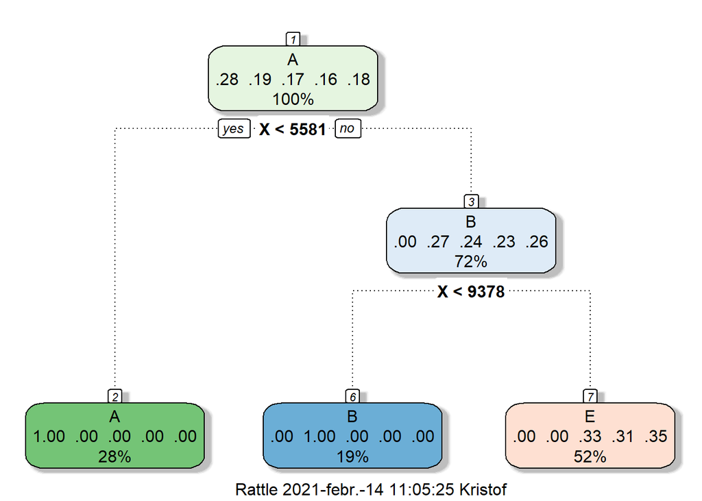

```r
fancyRpartPlot(mod1$finalModel)
```

```r
pred1<-predict(mod1,validSet)
table(validSet$classe,pred1)
```

```
##    pred1
##        A    B    C    D    E
##   A 1395    0    0    0    0
##   B    0  949    0    0    0
##   C    0    0    0    0  855
##   D    0    0    0    0  804
##   E    0    0    0    0  901
```

```r
acc1<-mean(validSet$classe==pred1)
```

The Accuracy of this model is 66.1704731%. This is not so bad, but we can create much more better Model. This is Random Forest. Firstly, I will run random forest with different number of trees (1 to 50) and I predict the validation set **validSet**. I plot the accuracy of the modell as a function of the number of the trees in the random forest.

```r
B<-50
Accuracy<-rep(0,B)
tic()
for(i in 1:B){
        mod2<-train(classe~.,data=trainSet, method="rf", ntree=i)
        pred2<-predict(mod2,validSet)
        Accuracy[i]<-mean(validSet$classe==pred2)
}
toc()
```

```
## 6103.03 sec elapsed
```

```r
print(Accuracy)
```

```
##  [1] 0.9997961 0.9997961 0.9995922 0.9997961 0.9995922 0.9997961 0.9997961
##  [8] 0.9997961 0.9995922 0.9997961 0.9997961 0.9997961 1.0000000 0.9995922
## [15] 1.0000000 0.9997961 0.9997961 0.9997961 0.9997961 0.9997961 0.9997961
## [22] 0.9997961 0.9997961 0.9997961 0.9997961 0.9997961 0.9997961 0.9997961
## [29] 0.9997961 0.9997961 0.9997961 0.9995922 0.9997961 0.9997961 0.9997961
## [36] 0.9997961 0.9997961 0.9997961 0.9997961 0.9997961 0.9997961 0.9997961
## [43] 0.9997961 0.9997961 0.9997961 0.9997961 0.9997961 0.9997961 0.9997961
## [50] 0.9997961
```

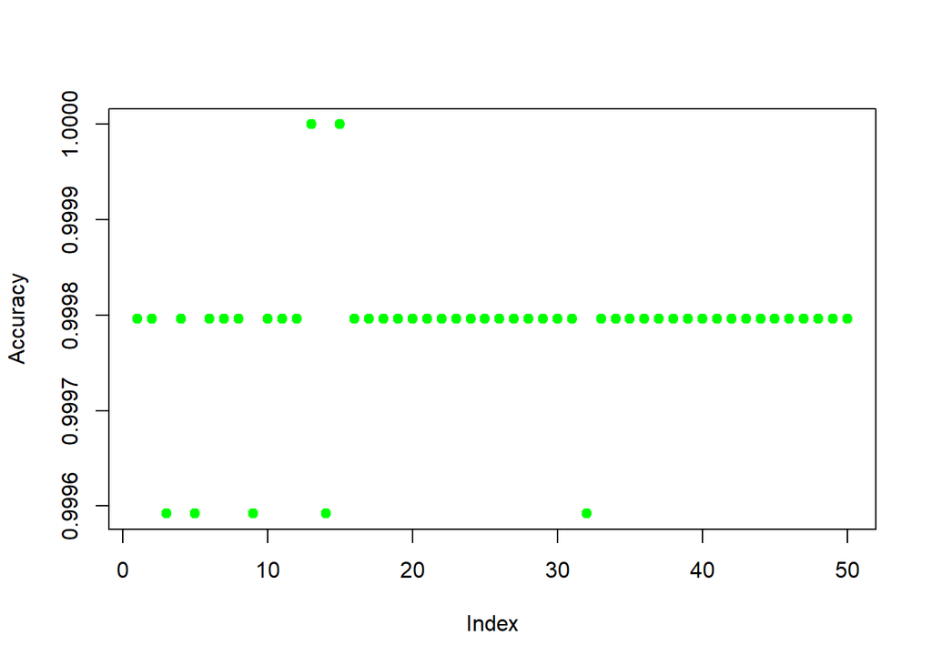

```r
plot(Accuracy,pch=19,cex=1,col='green')
```

```r
tic()
mod2<-train(classe~.,data=trainSet, method="rf", n.tree=30)
toc()
```

```
## 2187.84 sec elapsed
```

```r
pred2<-predict(mod2,validSet)
table(validSet$classe,pred2)
```

```
##    pred2
##        A    B    C    D    E
##   A 1395    0    0    0    0
##   B    1  948    0    0    0
##   C    0    0  855    0    0
##   D    0    0    0  804    0
##   E    0    0    0    0  901
```

```r
acc2<-mean(validSet$classe==pred2)
```

It can be seen that the accuracy of this model is much more higher: 99.9796085%.

## Prediction of the testing set:

Now let us joint the the **testing** set with the prediction of the second model.

```r
pred3<-predict(mod2,testing)
testing<-cbind(testing,pred3)
testing[,159:160]
```

```
##    problem_id pred3
## 1           1     A
## 2           2     A
## 3           3     A
## 4           4     A
## 5           5     A
## 6           6     A
## 7           7     A
## 8           8     A
## 9           9     A
## 10         10     A
## 11         11     A
## 12         12     A
## 13         13     A
## 14         14     A
## 15         15     A
## 16         16     A
## 17         17     A
## 18         18     A
## 19         19     A
## 20         20     A
```